# R Final Assignment

Jonathan Mark Hamonangan 2949398J EIDAR

## **Introduction**

This is a notebook for the processes that are done within R, like plotting and statistical analysis.

Same as the previous R scripts, we prepare the script with packages so the functions will run properly and to be recognized.

```r
# Reset / clear environment
rm(list = ls ())

# Load the necessary libraries
library(lme4)
library(lmtest)
```

```r
library(ggplot2)
library(dplyr)
library(tidyr)
library(ggeffects)
```

After resetting and loading the packages needed, we can start by assigning the main data object file and setting the variables. In this case we would like to set *mdr* as a factor, and instead of *0* and *1*, we will change it to *Present* and *Absent* so readers can understand more easily.

```r
# Load the data with the name amr
amr <- read.csv("AMR_data.csv")

# Convert MDR to a factor with custom labels (0 = Absent, 1 = Present)
amr$mdr <- factor(amr$mdr, levels = c(0, 1), labels = c("Absent", "Present"))

# Summary statistics of the data
summary(amr)
```

```
##        X             id                 mdr           abruse
##  Min.   :   1   Length:4186        Absent :1962   Min.   :1.000
##  1st Qu.:1047   Class :character   Present:2224   1st Qu.:2.000
##  Median :2094   Mode  :character                  Median :3.000
##  Mean   :2094                                     Mean   :3.062
##  3rd Qu.:3140                                     3rd Qu.:4.000
##  Max.   :4186                                     Max.   :6.000
##   boil_milk         diseased_animals_eaten  education          milk_consume
##  Length:4186        Length:4186            Length:4186        Min.   : 0.000
##  Class :character   Class :character       Class :character   1st Qu.: 2.000
##  Mode  :character   Mode  :character       Mode  :character   Median : 3.000
##                                                               Mean   : 3.857
##                                                               3rd Qu.: 6.000
##                                                               Max.   :10.000
```

## **Exploratory Visual Analysis**

Now that we have a proper main object file that we can use, we will now be plotting the variables to *mdr* to explore and visualize the data

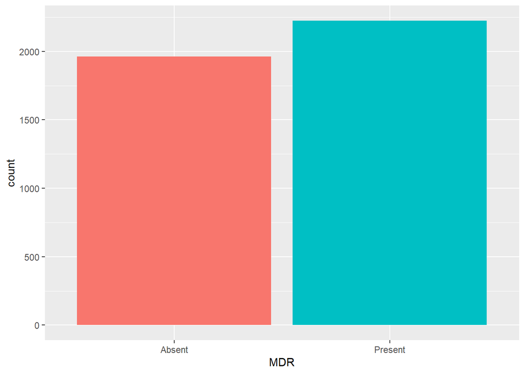

```r
# Basic ggplot code |
#-------------------
# ggplot(data, aes(x = var1, y = var 2, fill = var1,2,etc)) +
# geom_shape preffered + (aes for the shape etc) *add as needed
# labs( x = "label for x", y = "label for y", title = "title name") +
# *additional line of commands like coord_flip, theme, etc.

# Plotting the distribution of MDR as a bar graph
ggplot(amr, aes(x = mdr, fill = mdr)) +
  geom_bar() + # Bar graph
  labs(x = "MDR") +
  theme(legend.position = "none") # the legend will not be shown
```

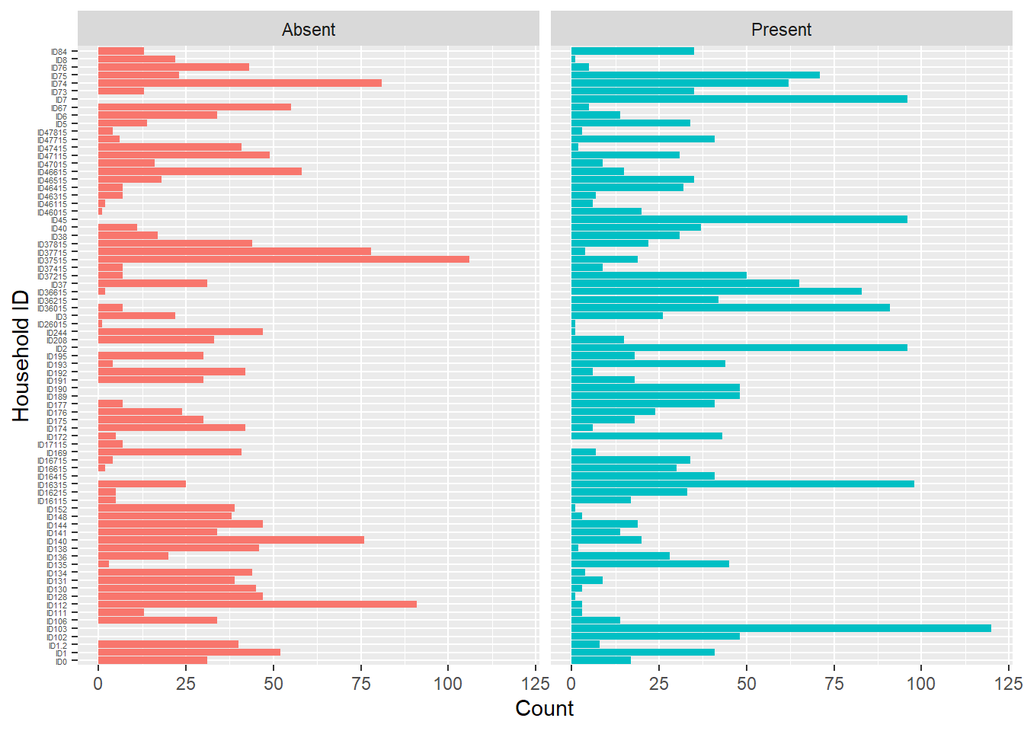

```r
# Creating a bar plot of household IDs by MDR status
ggplot(amr, aes(x = id, fill = mdr)) +
  geom_bar() +
  labs(x = "Household ID", y = "Count") +
  theme(axis.text.y = element_text(size = 4)) + # font size for y for visibility
  theme(legend.position = "none") +
  facet_wrap(~mdr) + # seperate plot by mdr presence
  coord_flip()  # flipping the x to y and vice versa
```

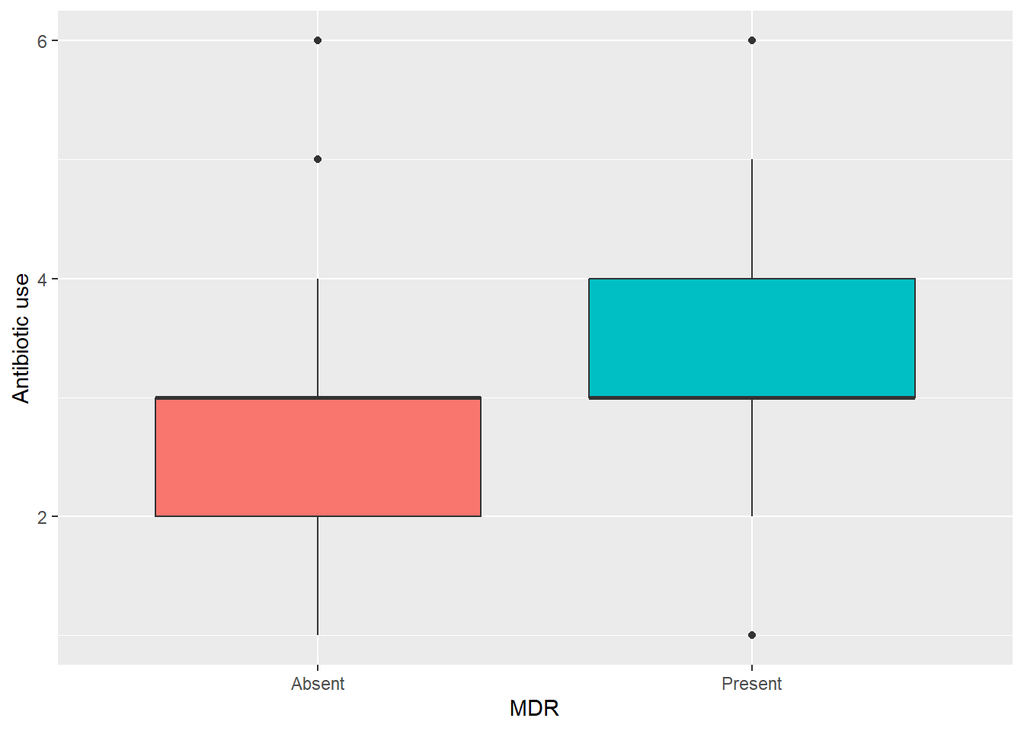

```r
# Box plot of antibiotic use by MDR status
ggplot(amr, aes(x = mdr, y = abruse, fill = mdr)) +
  geom_boxplot() +
  labs(x = "MDR", y = "Antibiotic use") +
  theme(legend.position = "none") # no legend
```

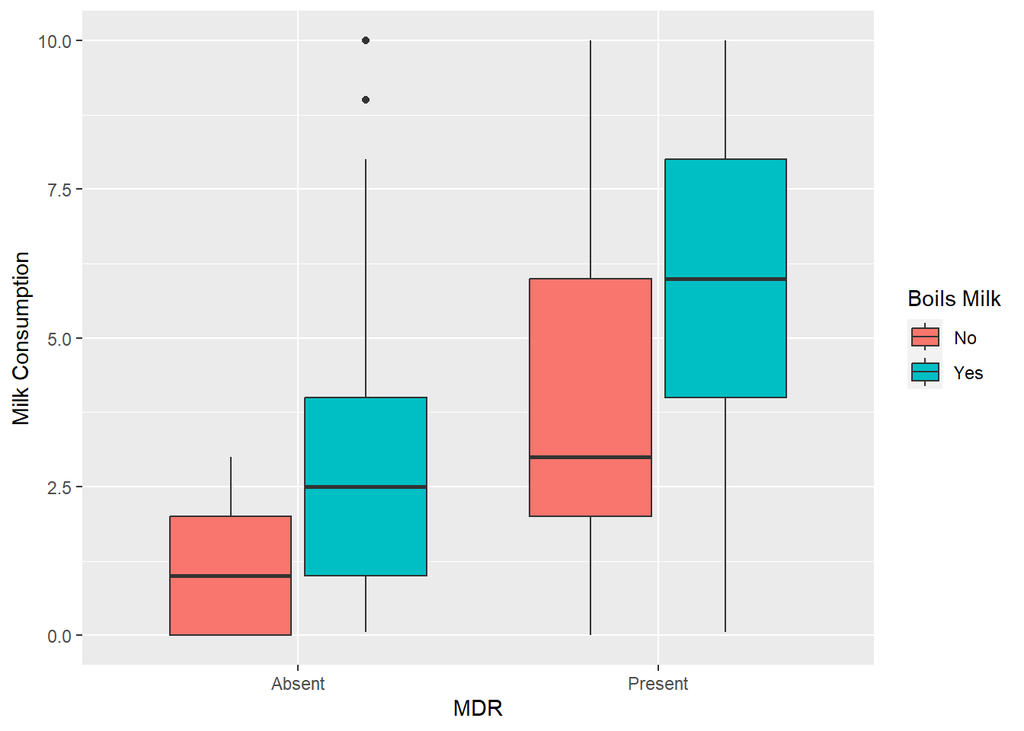

```r
# Scatter plot of milk consumption by MDR status
ggplot(amr, aes(x = mdr, y = milk_consume, fill = boil_milk)) +
  geom_boxplot() +
  labs(x = "MDR", y = "Milk Consumption") +
  guides(fill = guide_legend(title = "Boils Milk")) # assigns legend for the fill
```

We can also combine several plots into 1 to save space and perhaps for some who prefer it that way more.

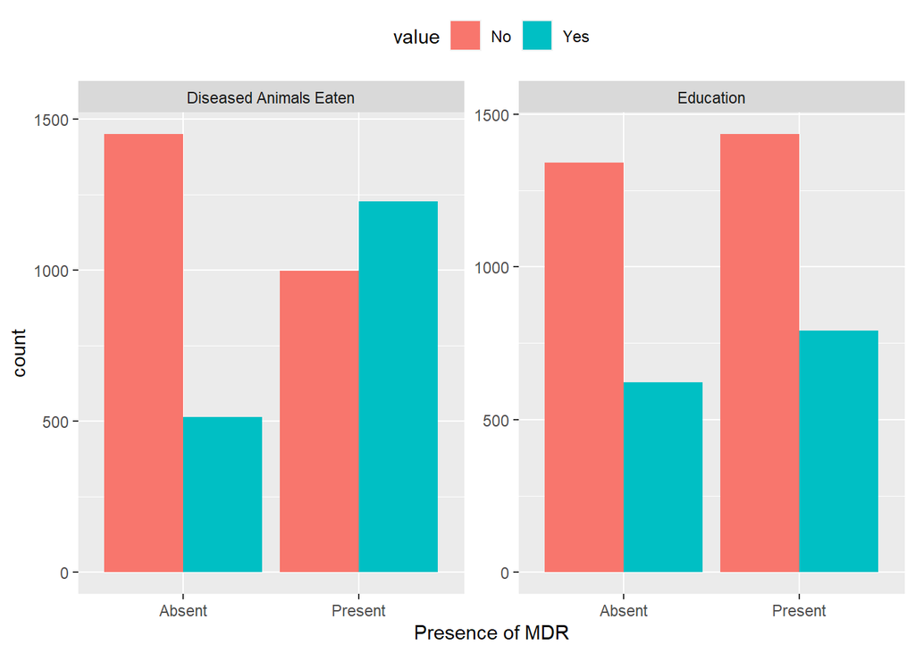

```r
# %>% or pipe operator chains together multiple operations

# Create a subset of the data with the desired variables
subset_data <- amr %>% #amr is the data being used
  select(mdr, education, diseased_animals_eaten) #selecting the variables of choice

# Melt the data for plotting
melted_data <- subset_data %>%
  pivot_longer(cols = c(education, diseased_animals_eaten), names_to = "variable", values_to = "value") # pivot_longer reshapes data where the columns chosen to be made into variable column for the characters, and value column for values

# Create a bar plot with facets and completely custom titles
ggplot(melted_data, aes(x = mdr, fill = value)) +
  geom_bar(position = "dodge") +
  facet_wrap(
    ~variable,
    scales = "free_y", # for different y-axis scales
    ncol = 2,   # arranges the facets in two columns
    labeller = labeller( # customizes the labels for the facets
      variable = c(
      education = "Education",
      diseased_animals_eaten = "Diseased Animals Eaten"))
  ) +
  labs(x = "Presence of MDR") +
  theme(legend.position = "top") # legend position to be on the top
```

## **GLMM**

Having plotted and visually assess the data, we will now do statistical analysis to answer the question *Which, if any, of the characteristics (antibiotic use, infection-related behaviours, etc) of the households are associated with (and therefore potentially risk factors for) MDR?*

The R glmer function, which fits Generalized Linear Mixed Models (GLMMs), is a component of the lme4 package. An expansion of generalized linear models (GLMs) that includes random and fixed effects is called a GLMM.

```r
# Basic glmer code |
#-------------------
# model name <- glmer(
# response variables ~ response variables + random intercept + chosen interactions,
# family = "family", data = data used,
# control = control parameter(optimizer)

# Define the GLMM model
model1 <- glmer(
  mdr ~ abruse + milk_consume + boil_milk + diseased_animals_eaten + education +
    (1 | id) + education:boil_milk + milk_consume:boil_milk,  # Random intercept for household ID
  family = binomial,  # Binomial distribution for binary response
  data = amr,
  control = glmerControl(optimizer = "bobyqa")
)
summary(model1)
```

```
## Generalized linear mixed model fit by maximum likelihood (Laplace
##   Approximation) [glmerMod]
##  Family: binomial  ( logit )
## Formula: mdr ~ abruse + milk_consume + boil_milk + diseased_animals_eaten +
##     education + (1 | id) + education:boil_milk + milk_consume:boil_milk
##    Data: amr
## Control: glmerControl(optimizer = "bobyqa")
##
##      AIC      BIC   logLik deviance df.resid
##   3373.7   3430.8  -1677.9   3355.7     4177
##
## Scaled residuals:
##     Min      1Q  Median      3Q     Max
## -6.1427 -0.4342  0.0013  0.4246  5.5160
##
## Random effects:
##  Groups Name        Variance Std.Dev.
##  id     (Intercept) 0.1273   0.3568
## Number of obs: 4186, groups:  id, 77
##
## Fixed effects:
##                           Estimate Std. Error z value Pr(>|z|)
## (Intercept)               -3.13196    0.35651  -8.785  < 2e-16 ***
## abruse                    -0.07207    0.08070  -0.893    0.372
## milk_consume               2.12558    0.16716  12.716  < 2e-16 ***
## boil_milkYes               0.40290    0.35311   1.141    0.254
## diseased_animals_eatenYes  0.66022    0.13787   4.789 1.68e-06 ***
## educationYes               0.04452    0.28143   0.158    0.874
## boil_milkYes:educationYes  0.05466    0.32205   0.170    0.865
## milk_consume:boil_milkYes -1.66351    0.16851  -9.872  < 2e-16 ***
## ---
## Signif. codes:  0 '***' 0.001 '**' 0.01 '*' 0.05 '.' 0.1 ' ' 1
##
## Correlation of Fixed Effects:
##             (Intr) abruse mlk_cn bl_mlY dss__Y edctnY bl_Y:Y
## abruse      -0.489
## milk_consum -0.721 -0.084
## boil_milkYs -0.700 -0.113  0.783
## dssd_nmls_Y  0.028 -0.081 -0.135 -0.095
## educationYs  0.026 -0.123 -0.211  0.042  0.039
## bl_mlkYs:dY  0.018  0.018  0.200 -0.116 -0.061 -0.863
## mlk_cnsm:_Y  0.724  0.060 -0.985 -0.836  0.119  0.212 -0.193
```

```r
model2 <- glmer(
  mdr ~ milk_consume + boil_milk + diseased_animals_eaten +
    (1 | id) + milk_consume:boil_milk,
  family = binomial,
  data = amr,
  control = glmerControl(optimizer = "bobyqa")
)
summary(model2)
```

```
## Generalized linear mixed model fit by maximum likelihood (Laplace
##   Approximation) [glmerMod]
##  Family: binomial  ( logit )
## Formula: mdr ~ milk_consume + boil_milk + diseased_animals_eaten + (1 |
##     id) + milk_consume:boil_milk
##    Data: amr
## Control: glmerControl(optimizer = "bobyqa")
##
##      AIC      BIC   logLik deviance df.resid
##   3368.7   3406.8  -1678.4   3356.7     4180
##
## Scaled residuals:
##     Min      1Q  Median      3Q     Max
## -6.2096 -0.4395  0.0013  0.4263  5.3870
##
## Random effects:
##  Groups Name        Variance Std.Dev.
##  id     (Intercept) 0.129    0.3591
## Number of obs: 4186, groups:  id, 77
##
## Fixed effects:
##                           Estimate Std. Error z value Pr(>|z|)
## (Intercept)                -3.2907     0.3109 -10.585  < 2e-16 ***
## milk_consume                2.1160     0.1627  13.005  < 2e-16 ***
## boil_milkYes                0.3963     0.3453   1.148    0.251
## diseased_animals_eatenYes   0.6554     0.1374   4.770 1.84e-06 ***
## milk_consume:boil_milkYes  -1.6579     0.1644 -10.082  < 2e-16 ***
## ---
## Signif. codes:  0 '***' 0.001 '**' 0.01 '*' 0.05 '.' 0.1 ' ' 1
##
## Correlation of Fixed Effects:
##             (Intr) mlk_cn bl_mlY dss__Y
## milk_consum -0.909
## boil_milkYs -0.887  0.825
## dssd_nmls_Y -0.012 -0.140 -0.122
## mlk_cnsm:_Y  0.897 -0.984 -0.879  0.122
```

```r
# Likelihood ratio test
# Compares nested models and assess whether the inclusion of certain terms significantly improves the model fit
lrtest(model1, model2)
```

```
## Likelihood ratio test
##
## Model 1: mdr ~ abruse + milk_consume + boil_milk + diseased_animals_eaten +
##     education + (1 | id) + education:boil_milk + milk_consume:boil_milk
## Model 2: mdr ~ milk_consume + boil_milk + diseased_animals_eaten + (1 |
##     id) + milk_consume:boil_milk
##   #Df  LogLik Df  Chisq Pr(>Chisq)
## 1   9 -1677.9
## 2   6 -1678.4 -3 1.0101     0.7988
```

Once the model has been fitted, we can use the summary function to get a model summary that includes z-values, p-values, fixed effect estimates, and standard errors.

```r
# Summarize the chosen model
summary(model2)
```

```
## Generalized linear mixed model fit by maximum likelihood (Laplace
##   Approximation) [glmerMod]
##  Family: binomial  ( logit )
## Formula: mdr ~ milk_consume + boil_milk + diseased_animals_eaten + (1 |
##     id) + milk_consume:boil_milk
##    Data: amr
## Control: glmerControl(optimizer = "bobyqa")
##
##      AIC      BIC   logLik deviance df.resid
##   3368.7   3406.8  -1678.4   3356.7     4180
##
## Scaled residuals:
##     Min      1Q  Median      3Q     Max
## -6.2096 -0.4395  0.0013  0.4263  5.3870
##
## Random effects:
##  Groups Name        Variance Std.Dev.
##  id     (Intercept) 0.129    0.3591
## Number of obs: 4186, groups:  id, 77
##
## Fixed effects:
##                           Estimate Std. Error z value Pr(>|z|)
## (Intercept)                -3.2907     0.3109 -10.585  < 2e-16 ***
## milk_consume                2.1160     0.1627  13.005  < 2e-16 ***
## boil_milkYes                0.3963     0.3453   1.148    0.251
## diseased_animals_eatenYes   0.6554     0.1374   4.770 1.84e-06 ***
## milk_consume:boil_milkYes  -1.6579     0.1644 -10.082  < 2e-16 ***
## ---
## Signif. codes:  0 '***' 0.001 '**' 0.01 '*' 0.05 '.' 0.1 ' ' 1
##
## Correlation of Fixed Effects:
##             (Intr) mlk_cn bl_mlY dss__Y
## milk_consum -0.909
## boil_milkYs -0.887  0.825
## dssd_nmls_Y -0.012 -0.140 -0.122
## mlk_cnsm:_Y  0.897 -0.984 -0.879  0.122
```

## **Prediction and Plotting**

Understanding and interpreting a model’s behaviour requires using prediction and its charting in statistical analysis. By using observed data, the predictive element enables us to assess the expected outcomes of the model. We can learn more about the relationships between the predictor variables and the response by using plots to visualize these predictions.

```r
# plotting ggpredict |
#--------------------
# model name <- ggpredict(model used, terms = c("variables"))
# plot(model name) + *the following are optional
# labs (title = "title name", x = "x label", y = "y label", color "color label")

# Predicting the model
ggpredict(model2)
```

```
## Data were 'prettified'. Consider using `terms="milk_consume [all]"` to
##   get smooth plots.
```

```
## $milk_consume
## # Predicted probabilities of mdr
##
## milk_consume | Predicted |       95% CI
## ---------------------------------------
##            0 |      0.04 | [0.02, 0.06]
##            1 |      0.24 | [0.18, 0.30]
##            3 |      0.96 | [0.93, 0.97]
##            4 |      0.99 | [0.99, 1.00]
##            5 |      1.00 | [1.00, 1.00]
##            6 |      1.00 | [1.00, 1.00]
##            7 |      1.00 | [1.00, 1.00]
##           10 |      1.00 | [1.00, 1.00]
##
## Adjusted for:
## *              boil_milk = No
## * diseased_animals_eaten = No
## *                     id = 0 (population-level)
```

```
##
## Not all rows are shown in the output. Use `print(..., n = Inf)` to show
##   all rows.
```

```
##
## $boil_milk
## # Predicted probabilities of mdr
##
## boil_milk | Predicted |       95% CI
## ------------------------------------
## No        |      0.99 | [0.98, 1.00]
## Yes       |      0.24 | [0.21, 0.28]
##
## Adjusted for:
## *           milk_consume = 3.86
## * diseased_animals_eaten =   No
## *                     id = 0 (population-level)
##
## $diseased_animals_eaten
## # Predicted probabilities of mdr
##
## diseased_animals_eaten | Predicted |       95% CI
## -------------------------------------------------
## No                     |      0.99 | [0.98, 1.00]
## Yes                    |      1.00 | [0.99, 1.00]
##
## Adjusted for:
## * milk_consume = 3.86
## *    boil_milk =   No
## *           id = 0 (population-level)
##
## attr(,"class")
## [1] "ggalleffects" "list"
## attr(,"model.name")
## [1] "model2"
```

```r
# Plotting the model prediction
# Visualizes predictions on the probability of MDR being influenced by milk consumption and boiling
model2predict1 <- ggpredict(model2, terms = c("milk_consume", "boil_milk"))
```

```
## Data were 'prettified'. Consider using `terms="milk_consume [all]"` to
##   get smooth plots.
```

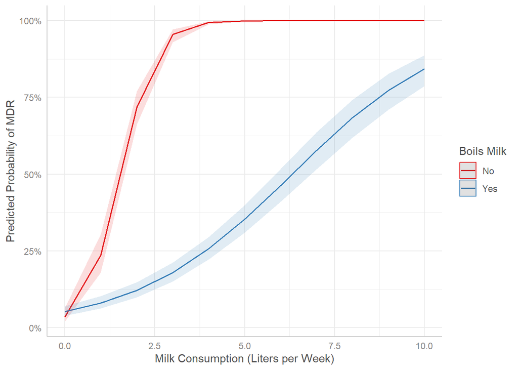

```r
plot(model2predict1) +
  labs(
    title = NULL, # removes title
    x = "Milk Consumption (Liters per Week)",
    y = "Predicted Probability of MDR",
    color = "Boils Milk"
  )
```

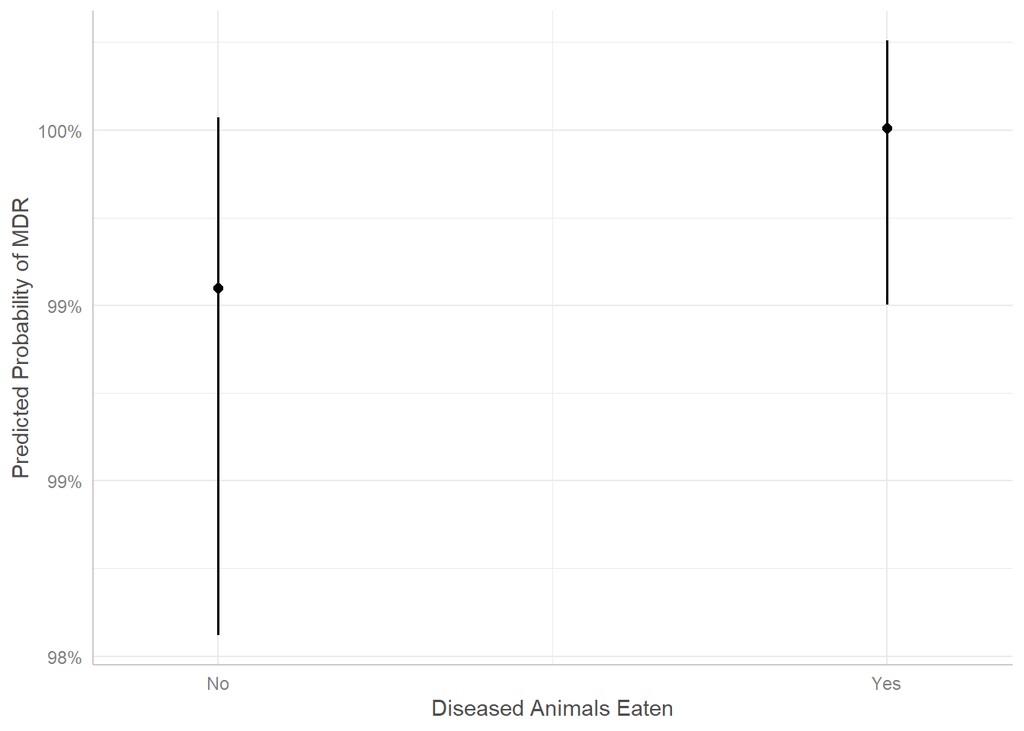

```r
# Visualizes predictions on the probability of MDR being influenced by the consumption of Diseased Animals
model2predict2 <- ggpredict(model2, terms = c("diseased_animals_eaten"))
plot(model2predict2) +
  labs(
    title = NULL,
    x = "Diseased Animals Eaten",
    y = "Predicted Probability of MDR",
    fill = "Diseased Animals Eaten"
  )
```

## **Odds Ratio**

Having done all of the analysis above, we will now calculate the odds ratio to quantify the impact of each predictor variable on the odds of MDR and to communicate the findings more interpretably. It helps answer questions like “How do the odds of MDR change due to different factors?” and provides a clearer picture for interpretation.

```r
# Calculate confidence intervals for the model
confint(model2)
```

```
## Computing profile confidence intervals ...
```

```
##                                2.5 %     97.5 %
## .sig01                     0.2463391  0.4967982
## (Intercept)               -3.9336529 -2.7010661
## milk_consume               1.8086404  2.4528895
## boil_milkYes              -0.2762253  1.0947258
## diseased_animals_eatenYes  0.3846071  0.9329665
## milk_consume:boil_milkYes -1.9969277 -1.3456814
```

```r
# Get coefficients from the model
model_coefficients <- fixef(model2) #fixef(model2) extracts the fixed-effects coefficients from model2

# Extract relevant coefficients
# exp() obtains the odds ratios
# model_coefficients["variable"] extracts the coefficient for the variable
odds_ratio_diseased_animals <-
  exp(model_coefficients["diseased_animals_eatenYes"])
odds_ratio_milk_consume <- exp(model_coefficients["milk_consume"])
odds_ratio_boiled_milk <- exp(model_coefficients["boil_milkYes"])
odds_ratio_milk_consume_boil_milk <- exp(model_coefficients["milk_consume:boil_milkYes"])

# Odds Ratio for consuming boiled milk
odds_ratio_milk_consume_boil_milkY <- 8.3*0.191 # Odds ratio milk consumption (non boiled)*boiled

# Print the odds ratios
cat("Odds Ratio for Eating Diseased Animals:", #prints values of the variable to the console.
    odds_ratio_diseased_animals)
```

```
## Odds Ratio for Eating Diseased Animals: 1.925843
```

```r
cat("Odds Ratio for Consuming Milk:", odds_ratio_milk_consume)
```

```
## Odds Ratio for Consuming Milk: 8.298078
```

```r
cat("Odds Ratio for Consuming Boiled Milk:", odds_ratio_boiled_milk)
```

```
## Odds Ratio for Consuming Boiled Milk: 1.486372
```

```r
cat("Odds Ratio for the interaction between Milk Consumption and Boiling Milk (Yes):", odds_ratio_milk_consume_boil_milk)
```

```
## Odds Ratio for the interaction between Milk Consumption and Boiling Milk (Yes): 0.1905411
```

## **References:**

Haydon, D., & Shaw, D. A pragmatist’s guide to General and Generalised Linear (Mixed) Models and inference (Version 1.2)

Posit. Data visualization with ggplot2 :: Cheat Sheet. https://rstudio.github.io/cheatsheets/html/data-visualization.html

Posit. RStudio IDE :: Cheatsheet. https://rstudio.github.io/cheatsheets/html/rstudio-ide.html

Posit. Data transformation with dplyr :: Cheatsheet. https://rstudio.github.io/cheatsheets/html/data-transformation.html

Posit. Data tidying with tidyr :: Cheatsheet. https://rstudio.github.io/cheatsheets/html/tidyr.html

Posit. rmarkdown :: Cheatsheet. https://rstudio.github.io/cheatsheets/html/rmarkdown.html

Armstrong, Dave. R By Example::Cheatsheet. https://quantoid.net/files/rbe/cheatsheet_full_draft.pdf